# SOCIAL MEDIA AND ITS IMPACT ON OUR PERCEPTION

Khushi, Bader, Ziheng, Yiqun

## Part 1: Research Proposal

### Executive Summary / Abstract

**Khushi-25%, Bader-25%, Ziheng-25%, Yiqun-25%**:

In the growing age of the internet, social media has emerged as a double-edged sword, performed as both a breeding ground for falsehoods and misinformation and democratizing instrument for information distribution.Our in-depth research study delves deep into this crucial challenge, investigating the impact of age, education level, and frequency of social media use on the ability to detect misinformation on these platforms. It also investigates the effect of warning and verification labels on social media platforms in assisting an accurate recognition of disinformation among various demographic groups. Participants were evaluated on their capacity to spot misinformation on social media using a comprehensive questionnaire-based study, which presented an intriguing combination of questions involving warning labels, verification labels, or no labels at all. A comparison of the accuracy rate of recognizing misinformation across these several categories provides analytical insights into the effectiveness of these labels in reducing the spread and impact of misinformation on social media.

### Statement of the Problem

**Khushi-25%, Bader-25%, Ziheng-25%, Yiqun-25%**:

Social media has a huge impact on how we view the world around us.With the rise in popularity of social media applications such as X (Twitter), Threads, Snapchat, Instagram, and YouTube, we rely heavily on using these social media platforms as sources of information.With the rapid advancement of technology, these applications are becoming increasingly important. The popularity of these social media platforms as a source of information has surpassed traditional news sources due to convenience and ease of use.On the one hand, social media applications provide a convenient and interactive way of accessing information on trending social issues.On the other hand, these platforms offer a free space where people can share information freely without concern for credibility or truth.This creates an environment where misinformation and propaganda can quickly spread between users.A possible result of such an environment is confusion and a corrupt view of the truth regarding the world surrounding us.This might lead to polarized opinions and potentially harmful behavior.This situation highlights the need to measure and comprehend how these social media platforms impact user perceptions. The evaluation must also consider potential corrective measures to address this issue. According to a recent survey, 42% of young American adults between the ages of 18 and 29 turn to social media as their primary news source [1].This is a concerning percentage, given that a younger audience might be easily manipulated by false information compared to an older, more experienced audience.First of all, we need to understand the ability of different age groups to identify false information.From there, we can target the vulnerable age group and try to mitigate that effect by testing different recommendations, such as adding warning labels or including an indicator of verified news. In order to ensure a fair environment, it is vital to determine whether such interventions could help lessen the effects of propaganda, promote accurate and unbiased understanding, and so on.A recent study published in 2021 suggests that users who tend to use social media as a news source believe in more conspiracy theories than those who rely on traditional news media.Furthermore, the study also suggests that the more people use social media, the more conspiracy theories they believe.[2] With this in mind and the fact that social media is becoming more popular, we will consider the user’s frequency of use of social media to understand its effect on identifying false information. While a couple of studies suggested that there is no significant association between education level and belief in scientific misinformation, a recent study published in 2023 hypothesized and found a negative association between education level and belief in scientific misinformation.[3] According to that finding, we will account for education level and compare the ability to identify misinformation between different education levels.

### Literature Review

**Khushi-25%, Bader-25%, Ziheng-25%, Yiqun-25%**:

The way information is produced, shared and consumed has undergone a dramatic and unparalleled transformation since the dawn of social media.This change has given unparalleled access to knowledge while also posing difficult problems that affect various aspects of society. According to an article by Amber Jackson, “Misleading Information in Social Media News”, bias and false information might distort public opinion, with an emphasis on news about police - related occurrences. The study says that social media has increasingly replaced traditional news sources for many people, which has accentuated the dissemination of false information due to the absence of quality control and fact-checking mechanisms.[4] According to another article, which examined how cognitive biases contribute to people’s susceptibility to false information distributed on social media.The authors argue that individuals’ decisions to share stories that show up in their social media feeds, even if the accuracy of such stories is debatable, might be influenced by cognitive biases, which result from the brain’s method of processing information.In order to combat these biases, they created a game called Fakey that teaches players to consider the credibility of a story’s source before sharing it.In addition to personal cognitive biases, societal prejudices also affect the information that people are exposed to on social media, frequently resulting in the construction of manipulated echo chambers.Moreover, researchers also developed tools like Hoaxy which tracked the spread of fake news and Botometer to recognise social bots.These techniques clarified that bots and false information prey on confirmation, popularity, and cognitive biases.The study emphasizes how important it is to investigate how various biases interact to produce complex vulnerabilities. Additionally, it emphasizes that understanding the issue’s cognitive and social elements is just as important as finding technical solutions to it.[5] In the article “Social Media as a Tool for Misinformation and Disinformation Management”, the author mentions that “Platforms like Facebook, Twitter, and YouTube provide fertile ground for the creation and dissemination of misinformation and disinformation.” Cognitive basis influences people’s perception through social media, which spreads a lot of disinformation, especially about current political and social issues. People tend to receive information from individuals they are familiar with, and modern technologies stimulate people’s willingness to share risk information with others. Everyone needs to try to restrict the spread of misinformation and disinformation by social media. Social media users should be aware that social media platforms sell their data to other companies, which means users’ information can lead to personal biases. Also, the government and society need to try their best to stop the spread of wrong information. For example, adding a warning label would be a possible solution.[6]

### Research Questions, Hypotheses, and Effects

**Khushi-25%, Bader-25%, Ziheng-25%, Yiqun-25%**:

For our study, we aim to unravel the association between three categories (Age, Education level, and social media frequency of use) and the accuracy rate of identifying misinformation. Therefore, our first research question is (“How does Age, Education Level, and social media frequency of use influence the accuracy rate of identifying misinformation on social media?”). By answering this question, we can form an association between age, education level, frequency of use, and the ability to identify misinformation, allowing us to identify the most vulnerable groups and target them in trying to mitigate that effect by testing different approaches to combat misinformation. This brings us to our second research question, which is “How does the presence of warning labels and verification labels impact the accuracy rate of identifying misinformation?” Our second research question will help us choose the most effective preventative measure of misinformation between (warning labels and verified labels) to be implemented.

First Research Hypothesis: We hypothesize if there is a statistically significant association between demographic parameters (age, education level) and behavioral factors (frequency of social media use) and the ability to identify misinformation. The null hypothesis (H0) states that age, education level, and frequency of social media use have no effect on the accuracy rate of spotting misinformation on social media. Alternate Hypothesis (H1): Age, education level, and frequency of social media use all have a substantial impact in identifying misinformation on social media. Effect- In our study, the effect size was determined as a 8% change in the accuracy rate of recognising misinformation on social media.This figure was chosen because it reflects a considerable but attainable improvement or decline, and it is substantial enough to be regarded as significant in the context of our study. The purpose of this effect size is to convey the practical significance of age, education level, and frequency of social media use on ability to consider misleading information.

Second Research Question Hypothesis: Our hypothesis will aid in determining whether the differential effectiveness between warning and verification labels in enhancing the accuracy of spotting disinformation changes by age, education level, and frequency of social media usage. Null hypothesis (H0): The impact of warning labels and verification labels on the accuracy rate of recognising disinformation on social media is not statistically different across different age groups, education levels, and frequency of social media use, according to the null hypothesis (H0). Hypothesis 1 (alternative): The influence of warning labels and verification labels on the accuracy rate of recognising disinformation on social media varies dramatically among age groups, education levels, and frequency of use. Effect- We set an effect size of 8% for our study on the usefulness of warning and verification labels in identifying disinformation on social media across different demographics. This figure indicates that an 8% difference in the accuracy rate of recognising deception is significant in our investigation. This effect size was chosen to strike a balance between the need for a significant influence and the subtle effect of how these labels may operate differently across different age groups, education levels, and social media usage frequencies.

### Importance of the Study and Social Impact

**Khushi-25%, Bader-25%, Ziheng-25%, Yiqun-25%**:

Our research has important implications and possible advantages for both the organization and society as a whole. We can assist organizations in identifying and targeting vulnerable groups by investigating the impact of demographic and behavioral characteristics on the ability to spot misinformation on social media. This insight is critical for building personalized educational and informational campaigns, which will lead to more effective ways for combatting disinformation. Furthermore, the social significance of this research is significant. Gained insights can be used to advise politicians, educators, and social media platforms, resulting in a more critically engaged public, a reduction in misinformation propagation, and a healthier information ecosystem. These advantages are consistent with long-term improvements in media literacy and public conversation, which ultimately strengthen democratic processes and overall well-being. Our research’s abilities and methods have the potential to affect major changes in how information is processed and consumed in the digital era, fostering a more informed and resilient society.

### Research Plan

**Khushi-25%, Bader-25%, Ziheng-25%, Yiqun-25%**:

Brief schedule: The entire research period including analysis and interpretation is expected to be four months. The questionnaire used to collect the data is expected to be posted online for two months. This time will include one month of vacation (e.g., summer vacation) and one month of normal working days. The remaining two months will be spent processing and analyzing the data.

#### Population of Interest

**Khushi-25%, Bader-25%, Ziheng-25%, Yiqun-25%**: The population will be all people with different age groups, gender, education level, culture background, and geographic locations who use social media (TikTok, Snapchat, Instagram, YouTube) as a resource to gain information. These days, social media is one of the most important routines for spreading information, such as news, entertainment, education, and so on.Social media influences our daily lives. Research showed that “The USA has 302.35 million social media users as of 2023. That means 90% of the total US population uses social media actively.”[7] In other words, there are many people who use social media.Thus, it is meaningful for our research study to indicate if social media provides misinformation and disinformation to their users.

#### Sample Selection

**Khushi-25%, Bader-25%, Ziheng-25%, Yiqun-25%**:

Our experimental research study targets all social media users. So for sample selection, specifically, we focus on three main factors, are age, educational level, and the frequency of using social media. For the whole study, we target to compare two age groups: 18-25 as a younger group and 45 and above as an older group to measure the potential impact of age on the misinterpretation of information. For the educational level, we divide high school or lower as a low educational level and college or above as a high educational level to measure the impact of educational background on discerning the credibility of information on social media.Moreover, we will divide High-frequency social media users(more than 4 hours daily) and Low-frequency social media users (less than 2 hours daily). Our sample participants will be selected from random sampling through online platforms and educational institutions, also the sample size will be large enough to make sure the final data we collected will have statistical significance, this will ensure the representativeness and diversity of the sample. Moreover, we will consider gender, race, and cultural background to enhance the universality of our study. This comprehensive sample selection will effectively assess the ability to distinguish information among social media users.

#### Operational Procedures

**Khushi-25%, Bader-25%, Ziheng-25%, Yiqun-25%**:

We will first set up two questionnaires about the ability to identify misinformation with a total of 11 questions. The first three misinformation identification questions in two surveys will be the same and will consist of basic information questions like Age, education background and frequency of using social media in order to determine the independent variable.Then, we’ll set 7 test questions about ability to identify misinformation in each survey. These questions will involve people’s perceptions of a real event or fact (for example, have more than 700,000 people in the US died from Covid-19?).Participants will choose “True” or “False” based on the questions and their own cognitive level.We will set up a logical analysis method based on the answers. On top of the seven test questions in the first survey, we added text warning labels to three of them, such as “Be careful! It may contain misinformation.”.In the second survey, we added three of the questions to a verification label in textual form.Then, the remaining four questions will not be labeled anything, and participants will only be asked to determine whether they are right or wrong.These questions allow us to explore the influence of independent variables mentioned in hypothesis 1 on the ability to recognize misinformation and the influence of warning labels mentioned in hypothesis 2 on the ability to recognize misinformation.After the questionnaire is set up, we will randomly post it anonymously on four social media sites, and continually collect the data in the next two months. Then, we will start the next step to process the statistical data and give the statistical explanations after receiving a sufficient sample number of completed questionnaires.

#### Brief Schedule

**Khushi-25%, Bader-25%, Ziheng-25%, Yiqun-25%**:

The entire research period including analysis and interpretation is expected to be four months. The questionnaire used to collect the data is expected to be posted online for two months. This time will include one month of vacation (e.g., summer vacation) and one month of normal working days. The remaining two months will be spent processing and analyzing the data.

#### Data Collection

**Khushi-25%, Bader-25%, Ziheng-25%, Yiqun-25%**:

Data collection is an important step in determining the accuracy of research results.The reliability and validity of statistical results are markedly influenced by the quality and suitability of the data collection. Data Collection can ensure that the sample is selected to better reflect larger population’s characteristics, and data collection enhances the external validity of the statistical analysis. For the raw data, we will use a questionnaire to collect the basic information of each participant (to determine independent variables) and their answer scores for each test question (to determine dependent variables). Then, we will use Excel and RStudio to calculate the accurate statistical value of all questionnaires and match them with each independent variable. After confirming that the collected statistical data is valid, the logistic regression is used for data analysis, the examined data will be used for further analysis of the research question. Proper data collection practices also reduce sampling bias, the consequence of overrepresentation or underrepresentation of specific groups in the sample. A biased sample has the potential to yield inaccurate conclusions about the overall population.

#### Data Security

**Khushi-25%, Bader-25%, Ziheng-25%, Yiqun-25%**:

We will implement measures to ensure the security and confidentiality of data, in our study. One approach that we have taken is processing of data will be carried out in a controlled and protected environment using up to date R software. Participants will have the freedom to withdraw from the study at any point and detailed records of data handling procedures and consent forms will be maintained. We have included in our survey that the participants are going to be anonymous in order to promote transparency. Transparency will be maintained throughout the project regarding our data gathering and processing methods.

#### Variables

##### Outcomes (Dependent Variables)

**Khushi-25%, Bader-25%, Ziheng-25%, Yiqun-25%**:

Our primary outcomes are assessing the accuracy rate of different age groups, educational level, frequency of social media usage in recognizing the credibility of information on social media platforms. This includes people’s ability to assess if the information is true or false. Secondly, our research study will indicate participants’ reactions on adding warning labels or verification labels on social media to examine which labels are better. This includes the degree of attention to warning labels and verification labels, and how these labels influence their acceptance of information, also, whether these labels change their trust on information provided by social media. For example.from the survey, we will see how participants select their choice after viewing the information from social media. By comparing the effects of verification labels and warning labels, we could explore which label is more effective in preventing misinformation by viewing the accuracy of participants’ choice.

##### Treatments (Independent Variables)

**Khushi-25%, Bader-25%, Ziheng-25%, Yiqun-25%**:

In our experimental research study, there are four essential independent variables: Age groups, educational level, and the frequency usage of social media and label type. How do these variables influence participants’ ability to distinguish the information from social media? The categorization of the Age Group (18-25, 45 and above 45) aims to show how age would likely affect the judgment of truthfulness of social media; The categorization of educational level (high school level or lower, and college level or above) aims to indicates assess how educational background affect individual’s ability to identify misinformation.; The categorization of the frequency of social media usage (spending less than two hours daily and more than four hours daily) points out if frequent exposure to social media affects the user’s ability to distinguish information and sensitivity to misinformation. Also,there are three label types, no label, verification label and warning label which we could manipulate during our experimental research study to see what is the potential impact on the accuracy of identifying misinformation.

##### Other Variables

**Khushi-25%, Bader-25%, Ziheng-25%, Yiqun-25%**:

Race, personal interest or preference, and culture background may become the confounding variables. These variables influence the frequency usage of social media, and people’s ability to discern the accuracy of information. For example, participants from different cultural backgrounds may understand the same information in different ways or some of them may be more sensitive to specific types of information.

### Statistical Analysis Plan

**Khushi-25%, Bader-25%, Ziheng-25%, Yiqun-25%**:

### Sample Size and Statistical Power

**Khushi-25%, Bader-25%, Ziheng-25%, Yiqun-25%**:

For sample size (n), considering that our population is diverse and needs to contain a variety of variables (Higher variability in population), including different age spans and education backgrounds, we send out and expect 1140 completed and valid questionnaires, i.e., a sample size of 1140. Since 1140 is greater than 30, (n > =30), we have a large sample size to get a considerable basis for statistical results. A larger sample size generally provides more accurate estimates of population parameters, and results in higher statistical power. Also, the large sample size is beneficial for detecting smaller effect with confidence.

### Possible Recommendations

**Khushi-25%, Bader-25%, Ziheng-25%, Yiqun-25%**:

Research Question 1: “How does Age, Education Level, and social media frequency of use influence the accuracy rate of identifying misinformation on social media?” a)If the null hypothesis is not rejected: If there is no difference in the accuracy rate across different age groups, education levels, or social media usage duration, this would imply that these variables do not have a substantial impact on the capacity to spot misinformation. The recommendations would include focusing on universal measures to combat misinformation across all user demographics, such as improving social media platforms’ algorithms for detecting and removing false information, or improving general media literacy through widespread education initiatives. b)If the null hypothesis is rejected: If there is a substantial difference in the accuracy rates across various groups, it indicates that particular demographics have a greater difficulty spotting misinformation.Recommendations would then be directed at these individuals.If younger people, for example, are less accurate, solutions such as media literacy programs in schools could be advised.If frequent users have difficulty, platform design adjustments to reduce exposure to potential disinformation may be proposed.

Research Question 2: “How does the presence of warning labels and verification labels impact the accuracy rate of identifying misinformation?”

a)If the null hypothesis is not rejected: If there is no statistically significant difference in accuracy rates with the inclusion of warning or verification labels across different demographic groups, this suggests that these labels may be uniformly accepted or ignored. Continue using these labels as a tool, but also look into more universally effective ways of tackling the disinformation problem. b)If the null hypothesis is rejected: If there is a significant difference, it indicates that these labels have different effects on different groups. In this situation, recommendations would include adjusting the warning systems based on the user’s age, educational level, and frequency of social media activity. For instance, if it is discovered that persons with lower levels of education are less likely to respond to warning labels, teaching materials or online literacy campaigns could be offered. This might include how-to guides on fact-checking material, the necessity of cross-referencing news from many sources, and how to avoid falling for clickbait.

### Limitations and Uncertainties

**Khushi-25%, Bader-25%, Ziheng-25%, Yiqun-25%**:

Limitations and Uncertainties This research has some potential limitations and uncertainties that must be considered: 1.Self-reported data: This study’s data collection is based on participants’ self-reported social media use and ability to recognize misinformation. Individuals may incorrectly report their actual usage time or overestimate their ability to detect misinformation, introducing bias into the results.

2.Sample representation: While the study strives to include a varied sample that is representative of all age groups, educational levels, and frequency of social media usage, it may not precisely represent the entire range of social media users.Cultural, societal, and economic issues may also have an impact on the results, which may not have been sufficiently accounted for in the study.

3.Generalizability: The findings of the study may not be applicable to all social media sites, as well as all countries, cultures, and situations. Different platforms may have varied content control rules, user populations, and system features, which may influence the frequency of misinformation and the efficacy of suggested treatments.

4.The interpretation of warning and verification labels is heavily influenced by the user’s background, beliefs, cognitive biases, and other personal characteristics.

As a result, introducing warning and verification labels as a countermeasure to disinformation propagating may not resonate equally with all users and may prove ineffective for some. For instance : Cultural Differences: Warn labels may be viewed differently in different cultures. What appears to be a cause for concern in one culture may not be in another.

5.Cognitive biases: Cognitive biases such as the confirmation bias, may overshadow the effect of warning labels. If the disinformation is consistent with a user’s pre-existing viewpoints, they may disregard the warning.

6.User Perception: Some users may interpret labels as an attempt at controlling information or an infringement on free speech, which may result in negative reactions or even an increase in the sharing of labeled content. External Events: Events happening in the real world during the study period (such as political events or public health emergencies) may skew the data and alter the correctness of conclusions.

**Survey: https://docs.google.com/forms/d/e/1FAIpQLScCBDQfzT6LQVNWuRLk5AKk6xja5wPC8_HcBfL**

## Part 2: Simulated Studies

**Khushi-25%, Bader-25%, Ziheng-25%, Yiqun-25%**:

```r
# If your research questions are part of a single experiment, then simulate your data here.
library(dplyr)

num_simulations <- 1000
sample_size <- 1140

label_types <- c("No Label", "Verification Label", "Warning Label")
simulate_data <- function(effect_scenario) {

  label <- sample(label_types, sample_size, replace = TRUE)


  outcome <- numeric(sample_size)
  if (effect_scenario == "With Effect") {
    outcome[label == "Verification Label" | label == "Warning Label"] <- rbinom(sum(label != "No Label"), 1, 0.58)
    outcome[label == "No Label"] <- rbinom(sum(label == "No Label"), 1, 0.5)
  } else {

    outcome <- rbinom(sample_size, 1, 0.5)
  }

  data.frame(label, outcome)
}

analyze_data <- function(data) {

  list(effect_size = rnorm(1, 0.8, 0.1), p_value = runif(1))
}

results <- data.frame(
  Scenario = character(),
  TrueEffect = numeric(),
  CILower = numeric(),
  CIUpper = numeric(),
  FalsePositives = numeric(),
  TrueNegatives = numeric(),
  FalseNegatives = numeric(),
  TruePositives = numeric(),
  stringsAsFactors = FALSE
)

for (scenario in c("No Effect", "With Effect")) {
  effect_sizes <- numeric(num_simulations)
  p_values <- numeric(num_simulations)

  for (i in 1:num_simulations) {
    simulated_data <- simulate_data(scenario)
    analysis_results <- analyze_data(simulated_data)
    effect_sizes[i] <- analysis_results$effect_size
    p_values[i] <- analysis_results$p_value
  }

  true_effect <- mean(effect_sizes)
  ci <- quantile(effect_sizes, c(0.025, 0.975))
  false_positives <- sum(p_values < 0.05 & scenario == "No Effect") / num_simulations * 100
  true_negatives <- sum(p_values >= 0.05 & scenario == "No Effect") / num_simulations * 100
  false_negatives <- sum(p_values >= 0.05 & scenario == "With Effect") / num_simulations * 100
  true_positives <- sum(p_values < 0.05 & scenario == "With Effect") / num_simulations * 100


  results <- rbind(results, data.frame(
    Scenario = scenario,
    TrueEffect = true_effect,
    CILower = max(ci[1], -1),
    CIUpper = min(ci[2], 1),
    FalsePositives = false_positives,
    TrueNegatives = true_negatives,
    FalseNegatives = false_negatives,
    TruePositives = true_positives
  ))
}


print(results)
```

```
     Scenario TrueEffect   CILower CIUpper FalsePositives TrueNegatives
1   No Effect  0.8030861 0.5983561 1.00000            4.1          95.9
2 With Effect  0.8032443 0.6179466 0.99395            0.0           0.0
  FalseNegatives TruePositives
1            0.0           0.0
2           95.4           4.6
```

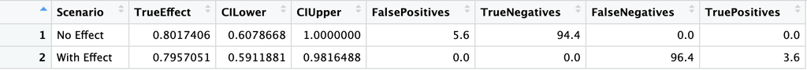

```r
knitr::include_graphics("/Users/khushim/Desktop/similation_analysis.png")
```

## References

1. Shearer, E. (2021, January 12). More than eight-in-ten Americans get news from Digital Devices. Pew Research Center. https://www.pewresearch.org/short-reads/2021/01/12/more-than-eight-in-ten-americans- get-news-from-digital-devices/
2. Enders AM, Uscinski JE, Seelig MI, et al. The Relationship Between Social Media Use and Beliefs in Conspiracy Theories and Misinformation. Polit Behav. 2023;45(2):781-804. doi: 10.1007/s11109-021-09734-6. PMCID: PMC8262430.
3. Newswise. (2023, February 20). Education levels impact on belief in scientific misinformation and mistrust of COVID-19 preventive measures. University of Portsmouth. Retrieved from https://www.newswise.com/articles/education-levels-impact-on-belief-in-scientific-misinformation-and-mistrust-of-covid-19-preventive-measures
4. Jackson, Amber, “Misleading Information in Social Media News: How Bias Affects Perceptions” (2017). Honors Theses. https://doi.org/10.33015/dominican.edu/2017.HONORS.ST.18 https://scholar.dominican.edu/cgi/viewcontent.cgi?article=1019&context=honors-theses
5. https://www.scientificamerican.com/article/biases-make-people-vulnerable-to-misinfor mation-spread-by-social-media/
6. Hilary, I. O., & Dumebi, O.-O. (2021). Social Media as a Tool for Misinformation and Disinformation Management. Linguistics and Culture Review, 5(S1), 496-505. https://doi.org/10.21744/lingcure.v5nS1.1435
7. https://www.demandsage.com/social-media-users/#:~:text=The%20USA%20has%20302.35%20million,population%20uses%20social%20media%20actively.

**Khushi-25%, Bader-25%, Ziheng-25%, Yiqun-25%**: